# Problem Set 3

Author

Peng Chen

Published

November 1, 2026

**GitHub repo:** https://github.com/perry-pezza/ec522_ps3_chen

## Data

### Data Preparation

```r
library(tidyverse)
library(fpp3)

retail_raw <- read_csv(
  "data/retail_sales_raw.csv",
  na = ".",
  col_types = cols(
    observation_date = col_date(format = "%Y-%m-%d"),
    RSAFS = col_double(),
    RSAFSNA = col_double()
  )
)

retail_raw_long <- retail_raw |>
  select(observation_date, RSAFS, RSAFSNA) |>
  pivot_longer(
    cols = c(RSAFS, RSAFSNA),
    names_to = "series_id",
    values_to = "sales"
  )

retail_ts <- retail_raw_long |>
  mutate(Month = yearmonth(observation_date)) |>
  as_tsibble(index = Month, key = series_id)

head(retail_ts)
```

```
# A tsibble: 6 x 4 [1M]
# Key:       series_id [1]
  observation_date series_id  sales    Month
  <date>           <chr>      <dbl>    <mth>
1 1992-01-01       RSAFS     159177 1992 1月
2 1992-02-01       RSAFS     159189 1992 2月
3 1992-03-01       RSAFS     158647 1992 3月
4 1992-04-01       RSAFS     159921 1992 4月
5 1992-05-01       RSAFS     160471 1992 5月
6 1992-06-01       RSAFS     161205 1992 6月
```

```r
has_gaps(retail_ts)
```

```
# A tibble: 2 × 2
  series_id .gaps
  <chr>     <lgl>
1 RSAFS     FALSE
2 RSAFSNA   FALSE
```

### Retail Sales Data Description

The retail sales data were downloaded from FRED and contain two monthly series: RSAFS (seasonally adjusted) and RSAFSNA (not seasonally adjusted).

The original observation_date column is stored as a Date. After converting the data into a tsibble, Month is the monthly time index, and series_id is the key that distinguishes the two retail sales series.

The dataset contains 417 months of observations for each series, from January 1992 to September 2026.

### Canadian Gas Production Data

The Canadian gas production data are included in the fpp3 package. They are monthly observations, with Month as the time index and no key variable because the dataset contains a single time series.

```r
head(canadian_gas)
```

```
# A tsibble: 6 x 2 [1M]
     Month Volume
     <mth>  <dbl>
1 1960 1月   1.43
2 1960 2月   1.31
3 1960 3月   1.40
4 1960 4月   1.17
5 1960 5月   1.12
6 1960 6月   1.01
```

```r
key_vars(canadian_gas)
```

```
character(0)
```

```r
index_var(canadian_gas)
```

```
[1] "Month"
```

```r
can_gas <- canadian_gas |>
  select(Month, Volume)

has_gaps(can_gas)
```

```
# A tibble: 1 × 1
  .gaps
  <lgl>
1 FALSE
```

```r
head(can_gas)
```

```
# A tsibble: 6 x 2 [1M]
     Month Volume
     <mth>  <dbl>
1 1960 1月   1.43
2 1960 2月   1.31
3 1960 3月   1.40
4 1960 4月   1.17
5 1960 5月   1.12
6 1960 6月   1.01
```

## Transformations

### Canadian Gas Production: Trend and Log Transformation

The Canadian gas production series is examined in its original and logarithmic forms. The trend plot helps identify long-term changes in production, while the logarithmic transformation makes proportional changes easier to interpret. The direct percentage growth rate and the log-difference approximation are then compared to assess how closely the two measures agree.

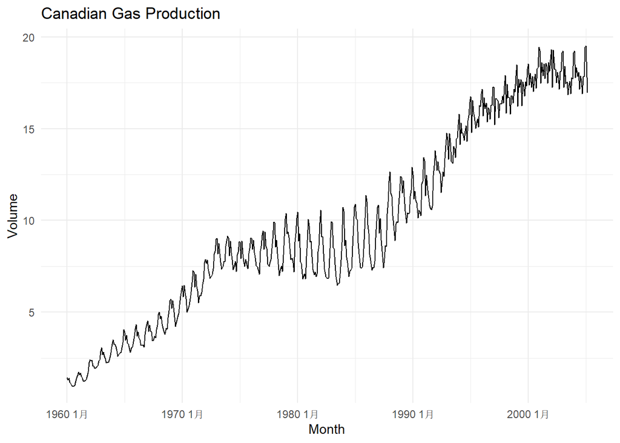

```r
can_gas |>
  autoplot(Volume) +
  labs(
    title = "Canadian Gas Production",
    x = "Month",
    y = "Volume"
  ) +
  theme_minimal()
```

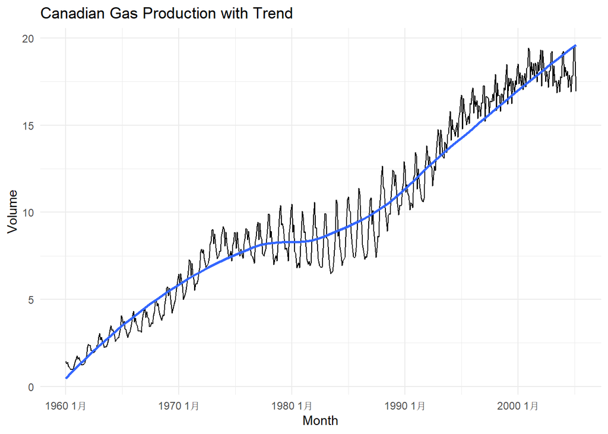

```r
can_gas |>
  autoplot(Volume) +
  geom_smooth(method = "loess", se = FALSE) +
  labs(
    title = "Canadian Gas Production with Trend",
    x = "Month",
    y = "Volume"
  ) +
  theme_minimal()
```

```r
can_gas <- can_gas |>
  mutate(log_volume = log(Volume))

head(can_gas)
```

```
# A tsibble: 6 x 3 [1M]
     Month Volume log_volume
     <mth>  <dbl>      <dbl>
1 1960 1月   1.43     0.358
2 1960 2月   1.31     0.267
3 1960 3月   1.40     0.338
4 1960 4月   1.17     0.157
5 1960 5月   1.12     0.110
6 1960 6月   1.01     0.0112
```

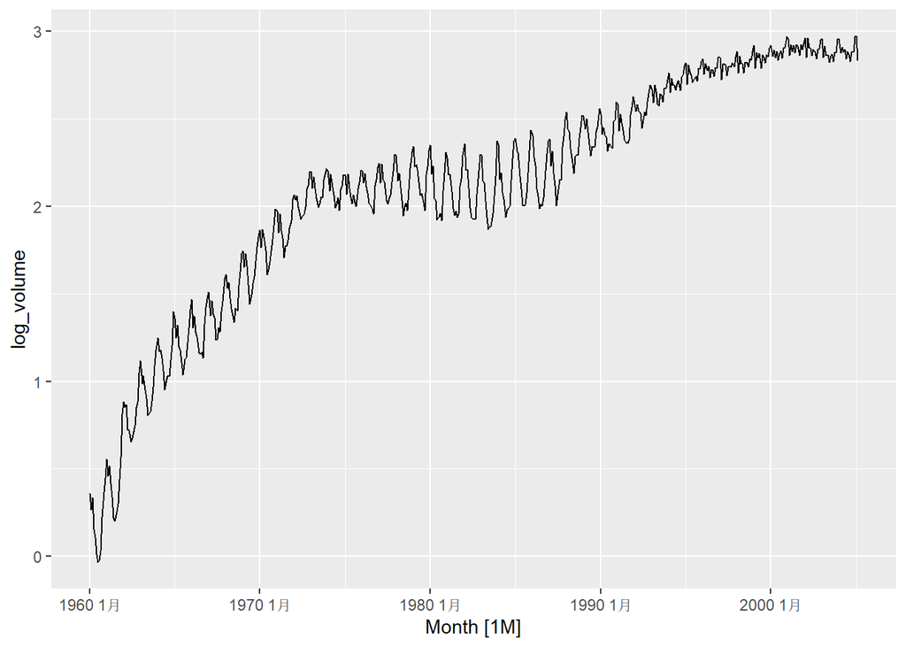

```r
can_gas |> autoplot(log_volume)
```

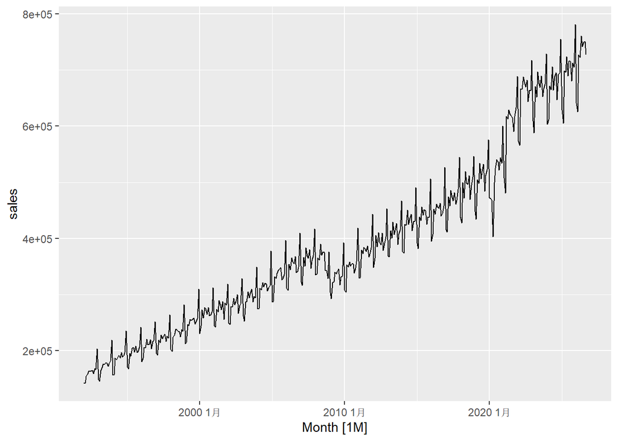

```r
retail_nsa <- retail_ts |>
  filter(series_id == "RSAFSNA") |>
  mutate(log_sales = log(sales))

retail_nsa |> autoplot(sales)
```

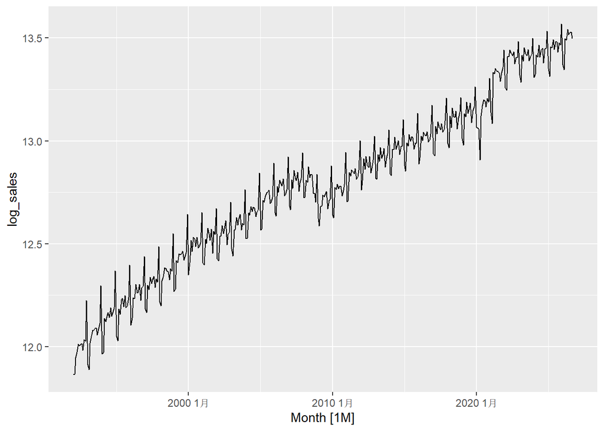

```r
retail_nsa |> autoplot(log_sales)
```

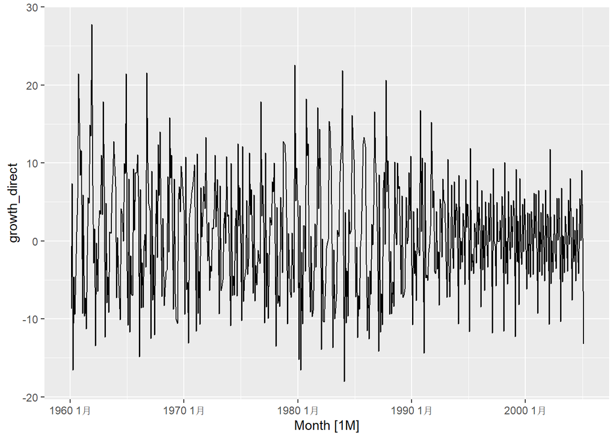

```r
can_gas <- can_gas |>
  mutate(
    growth_direct = 100 * difference(Volume) / lag(Volume),
    growth_logdiff = 100 * difference(log_volume)
  )
can_gas |> autoplot(growth_direct)
```

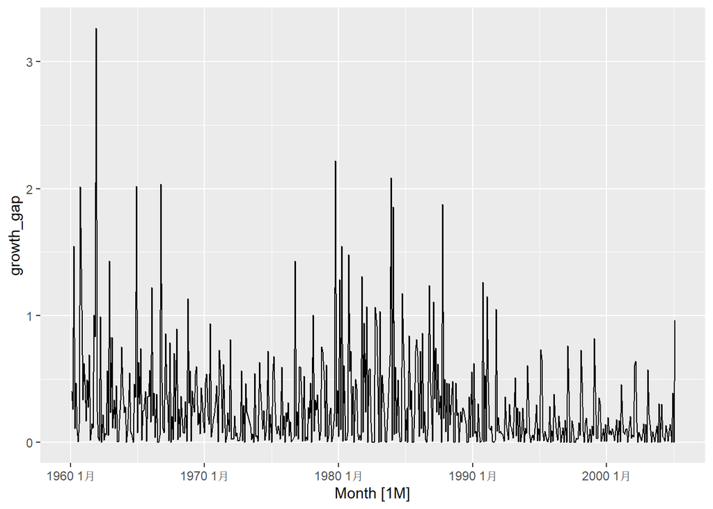

```r
can_gas <- can_gas |>
  mutate(growth_gap = abs(growth_direct - growth_logdiff))

can_gas |> autoplot(growth_gap)
```

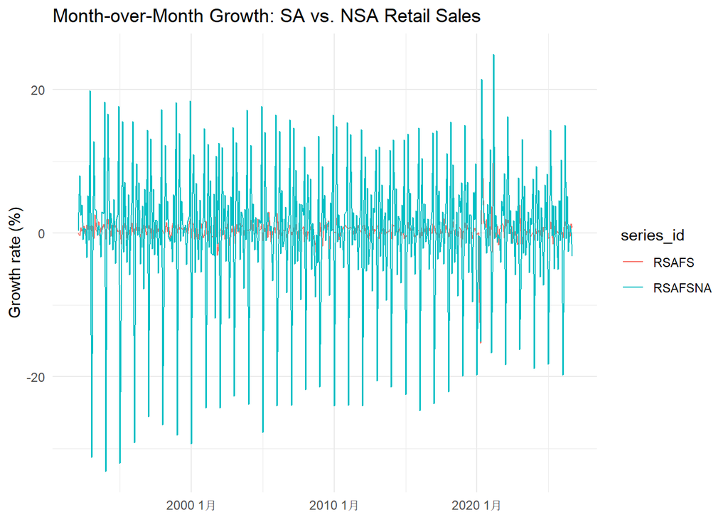

```r
retail_ts <- retail_ts |>
  group_by_key() |>
  mutate(growth_mom = 100 * difference(log(sales))) |>
  ungroup()

retail_ts |>
  autoplot(growth_mom) +
  labs(
    title = "Month-over-Month Growth: SA vs. NSA Retail Sales",
    x = NULL, y = "Growth rate (%)", color = NULL
  ) +
  theme_minimal()
```

The original Canadian gas production series and its smoothed trend illustrate changes in production over time. The logarithmic transformation allows changes to be interpreted in proportional terms rather than only in absolute units. The direct percentage growth rate and the log-difference approximation measure similar changes, with the approximation generally being more accurate for small percentage changes.

For retail sales, the comparison of monthly growth rates illustrates the effect of seasonal adjustment. The unadjusted series contains recurring seasonal fluctuations, whereas the adjusted series is intended to reduce these fluctuations, making underlying month-to-month movements easier to interpret.

## Seasonality

The seasonal plots compare seasonally adjusted (RSAFS) and non-seasonally adjusted (RSAFSNA) retail sales. The unadjusted series exhibits recurring monthly seasonal fluctuations, while these patterns are substantially reduced in the seasonally adjusted series. Seasonal adjustment therefore helps reveal underlying movements in retail sales more clearly, although it does not necessarily make the series stationary.

The seasonal and subseries plots of Canadian gas production are used to examine recurring within-year patterns. The X-13ARIMA-SEATS procedure is also applied to unadjusted retail sales, and the resulting adjusted series is compared with the Census Bureau’s published series. Differences between the two adjustments may arise from differences in model specifications, data vintages, or adjustment procedures.

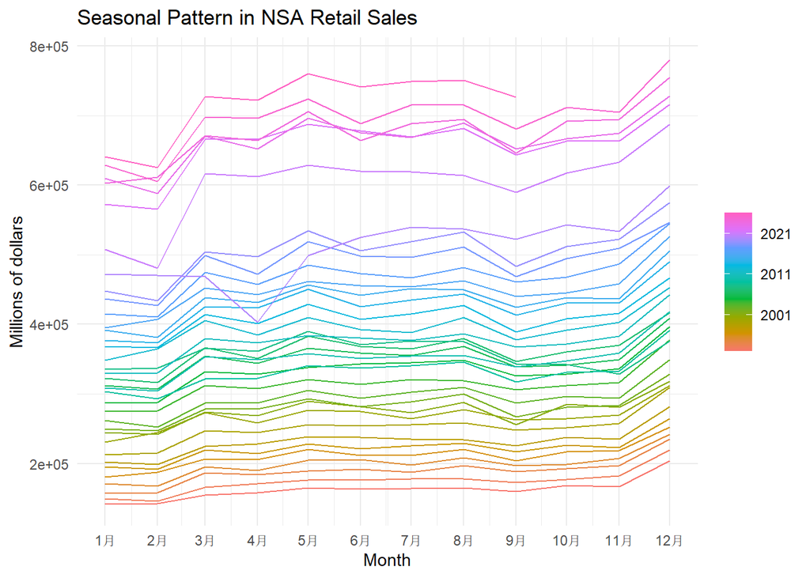

```r
retail_ts |>
  filter(series_id == "RSAFSNA") |>
  gg_season(sales) +
  labs(
    title = "Seasonal Pattern in NSA Retail Sales",
    y = "Millions of dollars"
  ) +
  theme_minimal()
```

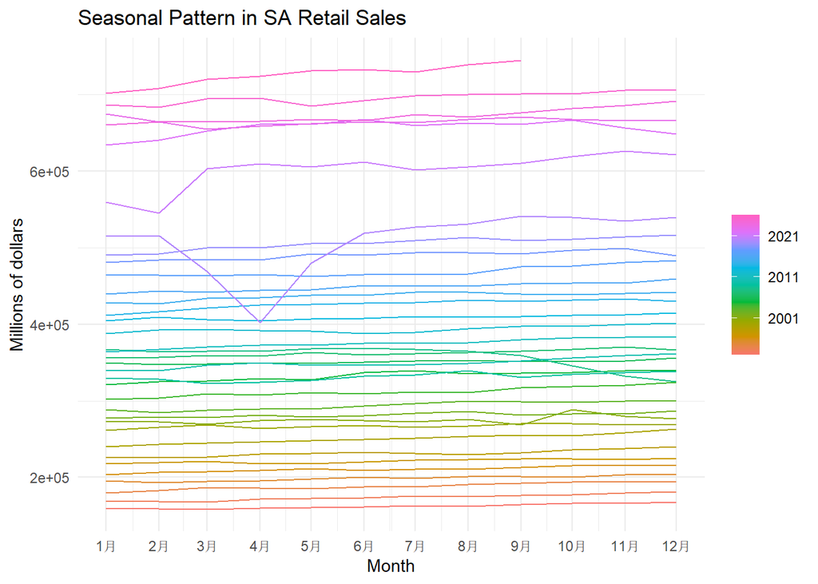

```r
retail_ts |>
  filter(series_id == "RSAFS") |>
  gg_season(sales) +
  labs(
    title = "Seasonal Pattern in SA Retail Sales",
    y = "Millions of dollars"
  ) +
  theme_minimal()
```

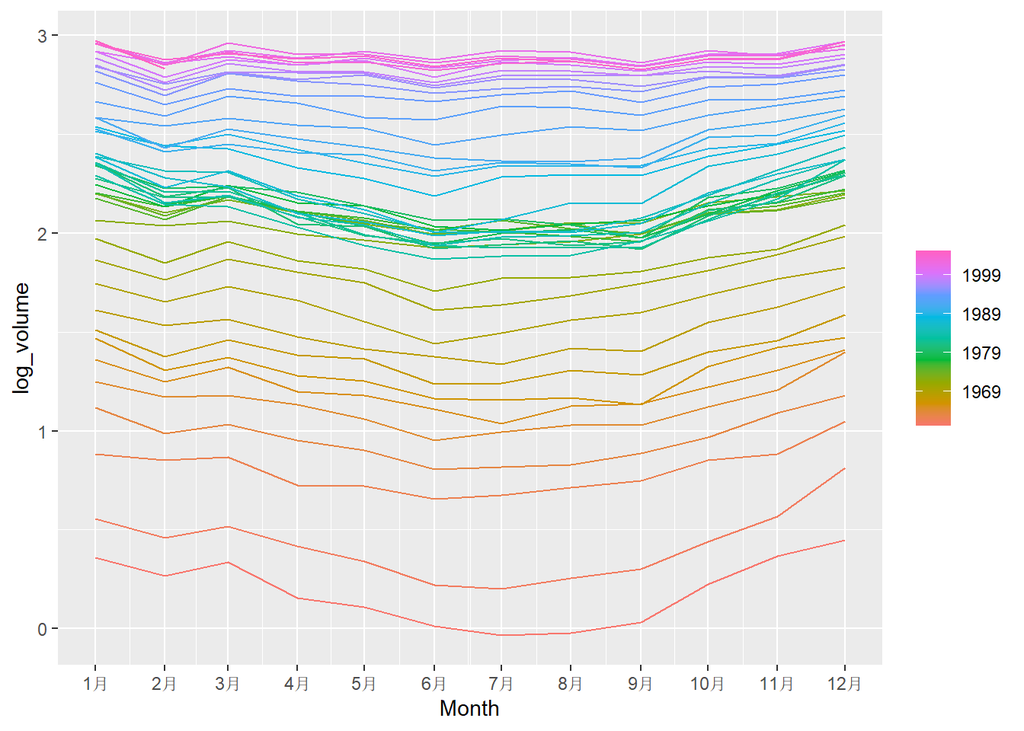

```r
can_gas |>
  gg_season(log_volume)
```

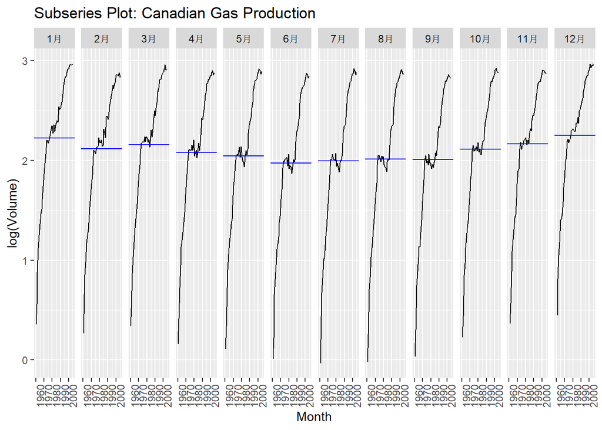

```r
can_gas |>
  gg_subseries(log_volume) +
  labs(
    title = "Subseries Plot: Canadian Gas Production",
    y = "log(Volume)"
  )
```

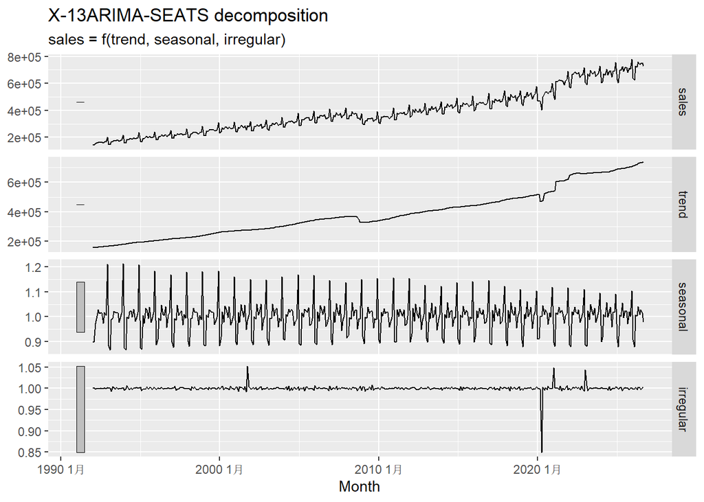

```r
retail_nsa_x13 <- retail_ts |>
  filter(series_id == "RSAFSNA") |>
  model(x13 = X_13ARIMA_SEATS(sales)) |>
  components()

retail_nsa_x13 |> autoplot()
```

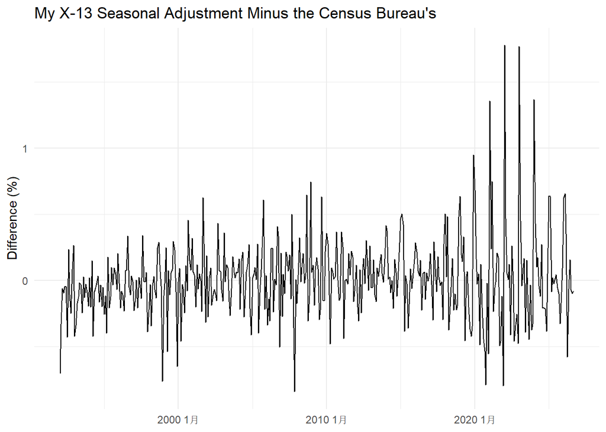

```r
sa_compare <- retail_nsa_x13 |>
  as_tibble() |>
  select(Month, mine = season_adjust) |>
  left_join(
    retail_ts |>
      filter(series_id == "RSAFS") |>
      as_tibble() |>
      transmute(Month, census = sales),
    by = "Month"
  ) |>
  mutate(pct_diff = 100 * (log(mine) - log(census)))

sa_compare |>
  ggplot(aes(x = Month, y = pct_diff)) +
  geom_line() +
  labs(
    title = "My X-13 Seasonal Adjustment Minus the Census Bureau's",
    x = NULL, y = "Difference (%)"
  ) +
  theme_minimal()
```

```r
can_gas_fit <- can_gas |>
  model(TSLM(log_volume ~ trend() + season()))

report(can_gas_fit)
```

```
Series: log_volume
Model: TSLM

Residuals:
      Min        1Q    Median        3Q       Max
-0.985307 -0.096451 -0.004525  0.131639  0.470564

Coefficients:
                 Estimate Std. Error t value Pr(>|t|)
(Intercept)     1.150e+00  4.142e-02  27.761  < 2e-16 ***
trend()         3.973e-03  6.886e-05  57.692  < 2e-16 ***
season()year2  -1.121e-01  5.229e-02  -2.144  0.03245 *
season()year3  -5.238e-02  5.258e-02  -0.996  0.31963
season()year4  -1.334e-01  5.258e-02  -2.537  0.01146 *
season()year5  -1.738e-01  5.258e-02  -3.305  0.00101 **
season()year6  -2.512e-01  5.258e-02  -4.777 2.30e-06 ***
season()year7  -2.300e-01  5.258e-02  -4.374 1.47e-05 ***
season()year8  -2.193e-01  5.258e-02  -4.170 3.56e-05 ***
season()year9  -2.274e-01  5.258e-02  -4.325 1.83e-05 ***
season()year10 -1.253e-01  5.258e-02  -2.383  0.01753 *
season()year11 -7.781e-02  5.258e-02  -1.480  0.13956
season()year12  7.202e-03  5.258e-02   0.137  0.89111
---
Signif. codes:  0 '***' 0.001 '**' 0.01 '*' 0.05 '.' 0.1 ' ' 1

Residual standard error: 0.2508 on 529 degrees of freedom
Multiple R-squared: 0.8652, Adjusted R-squared: 0.8622
F-statistic:   283 on 12 and 529 DF, p-value: < 2.22e-16
```

```r
can_gas_fit |>
  tidy() |>
  select(term, estimate, std.error, statistic, p.value) |>
  knitr::kable(digits = 3)
```

| term | estimate | std.error | statistic | p.value |
| --- | --- | --- | --- | --- |
| (Intercept) | 1.150 | 0.041 | 27.761 | 0.000 |
| trend() | 0.004 | 0.000 | 57.692 | 0.000 |
| season()year2 | -0.112 | 0.052 | -2.144 | 0.032 |
| season()year3 | -0.052 | 0.053 | -0.996 | 0.320 |
| season()year4 | -0.133 | 0.053 | -2.537 | 0.011 |
| season()year5 | -0.174 | 0.053 | -3.305 | 0.001 |
| season()year6 | -0.251 | 0.053 | -4.777 | 0.000 |
| season()year7 | -0.230 | 0.053 | -4.374 | 0.000 |
| season()year8 | -0.219 | 0.053 | -4.170 | 0.000 |
| season()year9 | -0.227 | 0.053 | -4.325 | 0.000 |
| season()year10 | -0.125 | 0.053 | -2.383 | 0.018 |
| season()year11 | -0.078 | 0.053 | -1.480 | 0.140 |
| season()year12 | 0.007 | 0.053 | 0.137 | 0.891 |

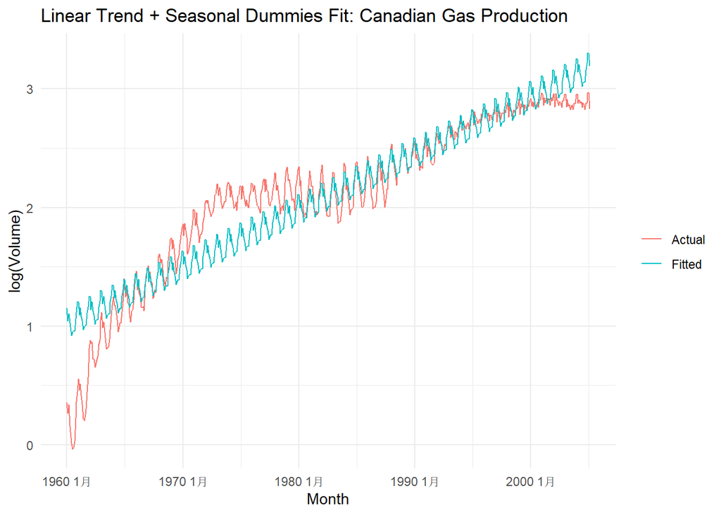

```r
can_gas_fit |>
  augment() |>
  ggplot(aes(x = Month)) +
  geom_line(aes(y = log_volume, color = "Actual")) +
  geom_line(aes(y = .fitted, color = "Fitted")) +
  labs(title = "Linear Trend + Seasonal Dummies Fit: Canadian Gas Production",
       y = "log(Volume)", color = NULL) +
  theme_minimal()
```

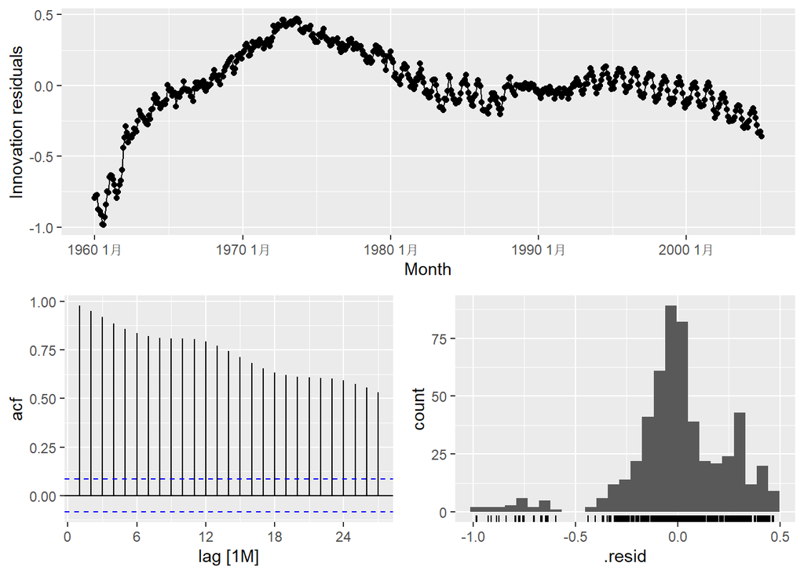

```r
can_gas_fit |> gg_tsresiduals()
```

```r
can_gas_fit |>
  augment() |>
  features(.innov, ljung_box, lag = 24) |>
  knitr::kable(digits = 3)
```

| .model | lb_stat | lb_pvalue |
| --- | --- | --- |
| TSLM(log_volume ~ trend() + season()) | 7774.218 | 0 |

A linear regression model with a time trend and monthly seasonal indicators is fitted to the logarithm of Canadian gas production. The fitted values are compared with the observed series, and residual diagnostics are used to evaluate the model. The Ljung–Box test examines whether the residuals exhibit remaining autocorrelation. A small p-value would indicate that the model has not fully captured the time-series dependence.

## Forecast Evaluation

One-step-ahead forecasts of Canadian gas production are evaluated using two competing models: a seasonal naive model (SNAIVE) and a linear trend plus seasonal regression model (TSLM). Both expanding-window and rolling-window forecasting procedures are considered. Forecast accuracy is measured using mean absolute error (MAE) and root mean squared error (RMSE). Lower values indicate better predictive accuracy.

```r
gas_cv_fc <- can_gas |>
  select(Month, Volume) |>
  stretch_tsibble(.init = 240, .step = 1) |>
  model(snaive = SNAIVE(Volume),
        tslm   = TSLM(log(Volume) ~ trend() + season())) |>
  forecast(h = 1)

gas_cv_fc |>
  accuracy(can_gas, measures = list(MAE = MAE, RMSE = RMSE)) |>
  knitr::kable(digits = 2)
```

| .model | .type | MAE | RMSE |
| --- | --- | --- | --- |
| snaive | Test | 0.56 | 0.70 |
| tslm | Test | 4.01 | 4.36 |

```r
errs <- gas_cv_fc |>
  as_tibble() |>
  left_join(as_tibble(can_gas) |> select(Month, actual = Volume),
            by = "Month") |>
  mutate(e = actual - .mean) |>
  select(Month, .model, e) |>
  pivot_wider(names_from = .model, values_from = e) |>
  na.omit()

forecast::dm.test(errs$snaive, errs$tslm, h = 1, power = 1)
```

```
    Diebold-Mariano Test

data:  errs$snaiveerrs$tslm
DM = -31.278, Forecast horizon = 1, Loss function power = 1, p-value <
2.2e-16
alternative hypothesis: two.sided
```

```r
gas_roll_fc <- can_gas |>
  select(Month, Volume) |>
  slide_tsibble(.size = 240, .step = 1) |>
  model(
    snaive = SNAIVE(Volume),
    tslm = TSLM(log(Volume) ~ trend() + season())
  ) |>
  forecast(h = 1)

gas_roll_fc |>
  accuracy(can_gas, measures = list(MAE = MAE, RMSE = RMSE)) |>
  knitr::kable(digits = 2)
```

| .model | .type | MAE | RMSE |
| --- | --- | --- | --- |
| snaive | Test | 0.56 | 0.70 |
| tslm | Test | 2.09 | 2.42 |

The Diebold–Mariano (DM) test is used to compare the predictive accuracy of the two forecasting methods. The test is based on paired one-step-ahead forecast errors and absolute-error loss. Its p-value is used to assess whether the difference in predictive performance is statistically significant. The expanding-window and rolling-window accuracy tables also allow us to compare how the choice of estimation window affects forecasting performance.

## Reflection

The analysis demonstrates the importance of distinguishing trend, seasonality, and short-term fluctuations in time-series data. For retail sales, seasonal adjustment reduces recurring monthly fluctuations, making underlying movements easier to identify. The logarithmic transformation also provides a useful way to examine proportional changes in Canadian gas production and retail sales.

For Canadian gas production, the linear trend and seasonal regression model does not fully capture the time-series dependence. The Ljung–Box test produces a p-value reported as approximately zero, indicating significant residual autocorrelation even after accounting for trend and seasonality.

In the expanding-window forecast evaluation, SNAIVE achieves an MAE of 0.562 and an RMSE of 0.702, substantially outperforming TSLM, which has an MAE of 4.01 and an RMSE of 4.36. The Diebold–Mariano test also indicates a statistically significant difference in predictive accuracy (DM = −31.278, p < 2.2 × 10⁻¹⁶).

In the rolling-window evaluation, SNAIVE maintains an MAE of 0.562 and an RMSE of 0.702. TSLM improves to an MAE of 2.09 and an RMSE of 2.42, but it still performs worse than SNAIVE.

Overall, the seasonal naive benchmark provides more accurate forecasts for this dataset. The results also suggest that including trend and seasonal indicators in a regression model does not guarantee good forecasting performance, particularly when significant autocorrelation remains in the residuals.